# Project: Investigate a Dataset (TMDB-Movies)

- Introduction
- Data Wrangling
- Exploratory Data Analysis
- Conclusions

## Introduction

> In this project, I will ba analyzing a dataset of 10,000 movies obtained from The Movie Database (TMDb). By using Python and python' libraries Numby, Pandas and Mayplotlip

> **Qustions:**
- What kinds of properties are associated with movies that have high revenues?
- which year has the most number of film produced?
- Highest film in terms of profits and lowest?

>

```python
#First call the neccessery library to analyse the data

import numpy as np
import pandas as pd
import matplotlib.pyplot as plt
import seaborn as sns
% matplotlib inline
```

## Data Wrangling

> **Tip**: In this section of the report, you will load in the data, check for cleanliness, and then trim and clean your dataset for analysis. Make sure that you document your steps carefully and justify your cleaning decisions.

### General Properties

```python
#Display the set
omv_df = pd.read_csv('tmdb-movies.csv')
omv_df.head(2)
```

|  | id | imdb_id | popularity | budget | revenue | original_title | cast | homepage | director | tagline | ... | overview | runtime | genres | production_companies | release_date | vote_count | vote_average | release_year | budget_adj | revenue_adj |
| --- | --- | --- | --- | --- | --- | --- | --- | --- | --- | --- | --- | --- | --- | --- | --- | --- | --- | --- | --- | --- | --- |
| 0 | 135397 | tt0369610 | 32.985763 | 150000000 | 1513528810 | Jurassic World | Chris Pratt\|Bryce Dallas Howard\|Irrfan Khan\|Vi... | http://www.jurassicworld.com/ | Colin Trevorrow | The park is open. | ... | Twenty-two years after the events of Jurassic ... | 124 | Action\|Adventure\|Science Fiction\|Thriller | Universal Studios\|Amblin Entertainment\|Legenda... | 6/9/15 | 5562 | 6.5 | 2015 | 1.379999e+08 | 1.392446e+09 |
| 1 | 76341 | tt1392190 | 28.419936 | 150000000 | 378436354 | Mad Max: Fury Road | Tom Hardy\|Charlize Theron\|Hugh Keays-Byrne\|Nic... | http://www.madmaxmovie.com/ | George Miller | What a Lovely Day. | ... | An apocalyptic story set in the furthest reach... | 120 | Action\|Adventure\|Science Fiction\|Thriller | Village Roadshow Pictures\|Kennedy Miller Produ... | 5/13/15 | 6185 | 7.1 | 2015 | 1.379999e+08 | 3.481613e+08 |

2 rows × 21 columns

```python
#overview of the dtat set
omv_df.info()
```

```
<class 'pandas.core.frame.DataFrame'>
RangeIndex: 10866 entries, 0 to 10865
Data columns (total 21 columns):
id                      10866 non-null int64
imdb_id                 10856 non-null object
popularity              10866 non-null float64
budget                  10866 non-null int64
revenue                 10866 non-null int64
original_title          10866 non-null object
cast                    10790 non-null object
homepage                2936 non-null object
director                10822 non-null object
tagline                 8042 non-null object
keywords                9373 non-null object
overview                10862 non-null object
runtime                 10866 non-null int64
genres                  10843 non-null object
production_companies    9836 non-null object
release_date            10866 non-null object
vote_count              10866 non-null int64
vote_average            10866 non-null float64
release_year            10866 non-null int64
budget_adj              10866 non-null float64
revenue_adj             10866 non-null float64
dtypes: float64(4), int64(6), object(11)
memory usage: 1.7+ MB
```

```python
omv_df.shape
```

```
(10866, 21)
```

```python
#overview of the statistics
omv_df.describe()
```

|  | id | popularity | budget | revenue | runtime | vote_count | vote_average | release_year | budget_adj | revenue_adj |
| --- | --- | --- | --- | --- | --- | --- | --- | --- | --- | --- |
| count | 10866.000000 | 10866.000000 | 1.086600e+04 | 1.086600e+04 | 10866.000000 | 10866.000000 | 10866.000000 | 10866.000000 | 1.086600e+04 | 1.086600e+04 |
| mean | 66064.177434 | 0.646441 | 1.462570e+07 | 3.982332e+07 | 102.070863 | 217.389748 | 5.974922 | 2001.322658 | 1.755104e+07 | 5.136436e+07 |
| std | 92130.136561 | 1.000185 | 3.091321e+07 | 1.170035e+08 | 31.381405 | 575.619058 | 0.935142 | 12.812941 | 3.430616e+07 | 1.446325e+08 |
| min | 5.000000 | 0.000065 | 0.000000e+00 | 0.000000e+00 | 0.000000 | 10.000000 | 1.500000 | 1960.000000 | 0.000000e+00 | 0.000000e+00 |
| 25% | 10596.250000 | 0.207583 | 0.000000e+00 | 0.000000e+00 | 90.000000 | 17.000000 | 5.400000 | 1995.000000 | 0.000000e+00 | 0.000000e+00 |
| 50% | 20669.000000 | 0.383856 | 0.000000e+00 | 0.000000e+00 | 99.000000 | 38.000000 | 6.000000 | 2006.000000 | 0.000000e+00 | 0.000000e+00 |
| 75% | 75610.000000 | 0.713817 | 1.500000e+07 | 2.400000e+07 | 111.000000 | 145.750000 | 6.600000 | 2011.000000 | 2.085325e+07 | 3.369710e+07 |
| max | 417859.000000 | 32.985763 | 4.250000e+08 | 2.781506e+09 | 900.000000 | 9767.000000 | 9.200000 | 2015.000000 | 4.250000e+08 | 2.827124e+09 |

```python
#Check if there is any null data and
omv_df.isna().sum()
```

```
id                         0
imdb_id                   10
popularity                 0
budget                     0
revenue                    0
original_title             0
cast                      76
homepage                7930
director                  44
tagline                 2824
keywords                1493
overview                   4
runtime                    0
genres                    23
production_companies    1030
release_date               0
vote_count                 0
vote_average               0
release_year               0
budget_adj                 0
revenue_adj                0
dtype: int64
```

```python
#Check duplicate!
omv_df.duplicated()

sum(omv_df.duplicated())
```

```
1
```

> **observation**: observation of the original dataset:
> - there are 21 clomuns and 10866 entries in the set
> - missing data in clomuns:(imdb_id, cast, homepage, director, tagline, keywords, overviews, genres, production_companies).
> - Null data in clomuns: ( imdb_id, cast, homepage, dierctor, tagline, keywords, overview, genres, production_companies).
> - (relesa_date) datatype is an object insted of date type.
> - there is 1 dublicate data in the set.
> - revenue and budget have 0 value in the thier rows
> - cast has multible entries in each cell

### Data Cleaning

> To Do
> - Drop uncessery cloumn
> - Remove Dublicate
> - drop Null values
> - replace missing data or 0 with mean

```python
#drop cloumns wont be helpful for answering the qustions and analysing the data
omv_df.drop(['id','imdb_id','homepage','tagline','keywords','overview','production_companies','release_date','budget_adj','revenue_adj'], axis=1, inplace=True)

#check it out!
omv_df.info()
```

```
<class 'pandas.core.frame.DataFrame'>
RangeIndex: 10866 entries, 0 to 10865
Data columns (total 11 columns):
popularity        10866 non-null float64
budget            10866 non-null int64
revenue           10866 non-null int64
original_title    10866 non-null object
cast              10790 non-null object
director          10822 non-null object
runtime           10866 non-null int64
genres            10843 non-null object
vote_count        10866 non-null int64
vote_average      10866 non-null float64
release_year      10866 non-null int64
dtypes: float64(2), int64(5), object(4)
memory usage: 933.9+ KB
```

```python
# remove dublicate!
omv_df.drop_duplicates(inplace=True)
```

```python
# Drop null!
omv_df.dropna(inplace=True)
```

```python
omv_df.info()
```

```
<class 'pandas.core.frame.DataFrame'>
Int64Index: 10731 entries, 0 to 10865
Data columns (total 11 columns):
popularity        10731 non-null float64
budget            10731 non-null int64
revenue           10731 non-null int64
original_title    10731 non-null object
cast              10731 non-null object
director          10731 non-null object
runtime           10731 non-null int64
genres            10731 non-null object
vote_count        10731 non-null int64
vote_average      10731 non-null float64
release_year      10731 non-null int64
dtypes: float64(2), int64(5), object(4)
memory usage: 1006.0+ KB
```

```python
#check it!
omv_df.describe()
```

|  | popularity | budget | revenue | runtime | vote_count | vote_average | release_year |
| --- | --- | --- | --- | --- | --- | --- | --- |
| count | 10731.000000 | 1.073100e+04 | 1.073100e+04 | 10731.000000 | 10731.000000 | 10731.000000 | 10731.000000 |
| mean | 0.652615 | 1.480365e+07 | 4.031989e+07 | 102.468829 | 219.812972 | 5.964710 | 2001.259622 |
| std | 1.004804 | 3.106456e+07 | 1.176524e+08 | 30.493873 | 578.815324 | 0.930283 | 12.820151 |
| min | 0.000188 | 0.000000e+00 | 0.000000e+00 | 0.000000 | 10.000000 | 1.500000 | 1960.000000 |
| 25% | 0.210765 | 0.000000e+00 | 0.000000e+00 | 90.000000 | 17.000000 | 5.400000 | 1995.000000 |
| 50% | 0.387081 | 0.000000e+00 | 0.000000e+00 | 99.000000 | 39.000000 | 6.000000 | 2006.000000 |
| 75% | 0.720889 | 1.600000e+07 | 2.500000e+07 | 112.000000 | 148.000000 | 6.600000 | 2011.000000 |
| max | 32.985763 | 4.250000e+08 | 2.781506e+09 | 900.000000 | 9767.000000 | 9.200000 | 2015.000000 |

```python
#replacing 0 in 'revenue' , 'budget' and 'runtime' with the mean of each.

revenue_mean = omv_df['revenue'].mean()

omv_df['revenue'].replace(0, revenue_mean, inplace=True)

budget_mean = omv_df['budget'].mean()

omv_df['budget'].replace(0, budget_mean , inplace=True)

runtime_mean = omv_df['runtime'].mean()

omv_df['runtime'].replace(0, runtime_mean , inplace=True)
```

```python
omv_df.head(5)
```

|  | popularity | budget | revenue | original_title | cast | director | runtime | genres | vote_count | vote_average | release_year |
| --- | --- | --- | --- | --- | --- | --- | --- | --- | --- | --- | --- |
| 0 | 32.985763 | 150000000.0 | 1.513529e+09 | Jurassic World | Chris Pratt\|Bryce Dallas Howard\|Irrfan Khan\|Vi... | Colin Trevorrow | 124.0 | Action\|Adventure\|Science Fiction\|Thriller | 5562 | 6.5 | 2015 |
| 1 | 28.419936 | 150000000.0 | 3.784364e+08 | Mad Max: Fury Road | Tom Hardy\|Charlize Theron\|Hugh Keays-Byrne\|Nic... | George Miller | 120.0 | Action\|Adventure\|Science Fiction\|Thriller | 6185 | 7.1 | 2015 |
| 2 | 13.112507 | 110000000.0 | 2.952382e+08 | Insurgent | Shailene Woodley\|Theo James\|Kate Winslet\|Ansel... | Robert Schwentke | 119.0 | Adventure\|Science Fiction\|Thriller | 2480 | 6.3 | 2015 |
| 3 | 11.173104 | 200000000.0 | 2.068178e+09 | Star Wars: The Force Awakens | Harrison Ford\|Mark Hamill\|Carrie Fisher\|Adam D... | J.J. Abrams | 136.0 | Action\|Adventure\|Science Fiction\|Fantasy | 5292 | 7.5 | 2015 |
| 4 | 9.335014 | 190000000.0 | 1.506249e+09 | Furious 7 | Vin Diesel\|Paul Walker\|Jason Statham\|Michelle ... | James Wan | 137.0 | Action\|Crime\|Thriller | 2947 | 7.3 | 2015 |

```python
omv_df.info()
```

```
<class 'pandas.core.frame.DataFrame'>
Int64Index: 10731 entries, 0 to 10865
Data columns (total 11 columns):
popularity        10731 non-null float64
budget            10731 non-null float64
revenue           10731 non-null float64
original_title    10731 non-null object
cast              10731 non-null object
director          10731 non-null object
runtime           10731 non-null float64
genres            10731 non-null object
vote_count        10731 non-null int64
vote_average      10731 non-null float64
release_year      10731 non-null int64
dtypes: float64(5), int64(2), object(4)
memory usage: 1006.0+ KB
```

```python
omv_df.describe()
```

|  | popularity | budget | revenue | runtime | vote_count | vote_average | release_year |
| --- | --- | --- | --- | --- | --- | --- | --- |
| count | 10731.000000 | 1.073100e+04 | 1.073100e+04 | 10731.000000 | 10731.000000 | 10731.000000 | 10731.000000 |
| mean | 0.652615 | 2.249862e+07 | 6.244304e+07 | 102.736197 | 219.812972 | 5.964710 | 2001.259622 |
| std | 1.004804 | 2.814008e+07 | 1.116267e+08 | 30.040062 | 578.815324 | 0.930283 | 12.820151 |
| min | 0.000188 | 1.000000e+00 | 2.000000e+00 | 3.000000 | 10.000000 | 1.500000 | 1960.000000 |
| 25% | 0.210765 | 1.480365e+07 | 4.024287e+07 | 90.000000 | 17.000000 | 5.400000 | 1995.000000 |
| 50% | 0.387081 | 1.480365e+07 | 4.031989e+07 | 99.000000 | 39.000000 | 6.000000 | 2006.000000 |
| 75% | 0.720889 | 1.600000e+07 | 4.031989e+07 | 112.000000 | 148.000000 | 6.600000 | 2011.000000 |
| max | 32.985763 | 4.250000e+08 | 2.781506e+09 | 900.000000 | 9767.000000 | 9.200000 | 2015.000000 |

Now the data looks clean, I can move to the next step and start exploring the data and answering the qustion posted early...

## Exploratory Data Analysis

> **Tip**: Now that you've trimmed and cleaned your data, you're ready to move on to exploration. Compute statistics and create visualizations with the goal of addressing the research questions that you posed in the Introduction section. It is recommended that you be systematic with your approach. Look at one variable at a time, and then follow it up by looking at relationships between variables.

[output not shown]

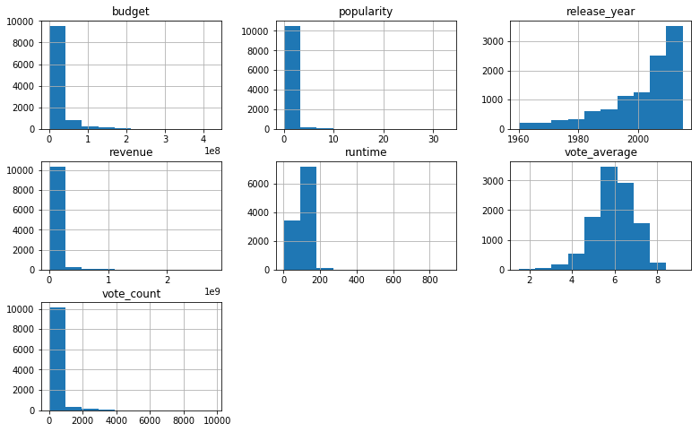

```python
#visualize the data with histogram to have clera overlook
omv_df.hist(figsize=(13,8))
```

### Research Question 1 (What kinds of properties are associated with movies that have high revenues?)

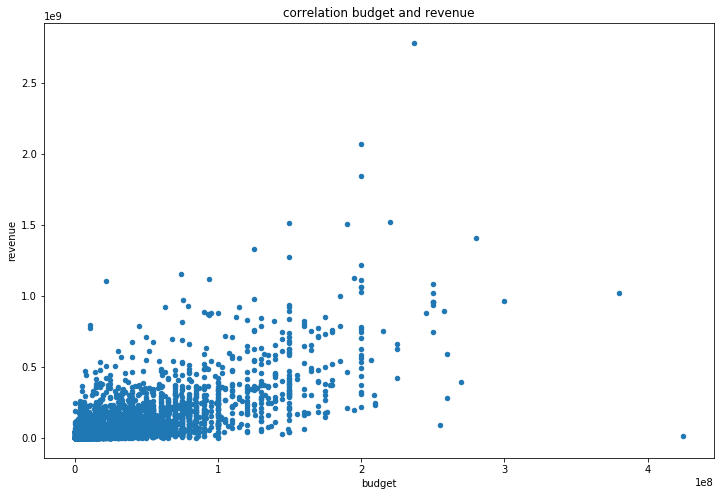

```python
#Test the relationship between revenue and budjet and how the correlate with each other
omv_df.plot(x= 'budget', y='revenue', kind='scatter', title= "correlation budget and revenue", figsize=(12,8))
```

We can motice there is postive reltaionship betwen revenue and budget but it is not strong relationship

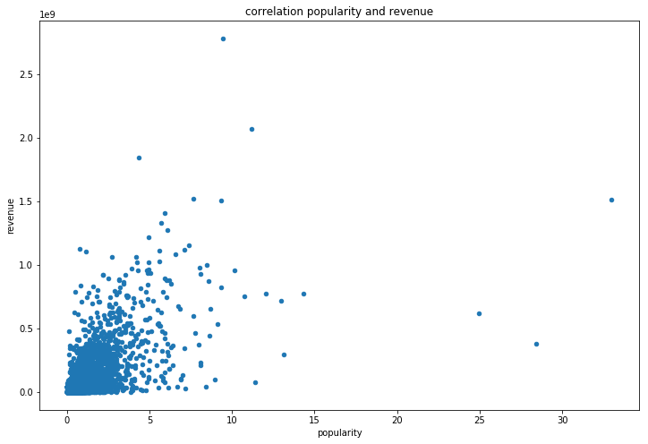

```python
#Test the relationship between revenue and popularity and how the corllete with each other
omv_df.plot(x= 'popularity', y='revenue', kind='scatter', title= "correlation popularity and revenue", figsize=(12,8))
```

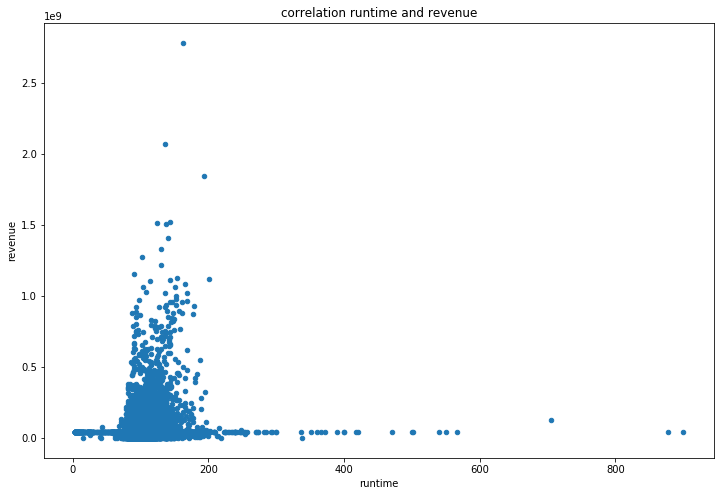

```python
#Test the relationship between revenue and runtime and how the corllete with each other

omv_df.plot(x= 'runtime', y='revenue', kind='scatter', title= "correlation runtime and revenue", figsize=(12,8))
```

Long run-time or short run-time dont have hight revenuew

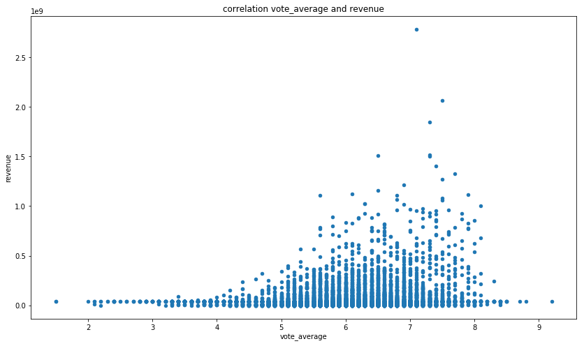

```python
#Test the relationship between revenue and vote average and how the corllete with each other

omv_df.plot(x= 'vote_average', y='revenue', kind='scatter', title= "correlation vote_average and revenue", figsize=(14,8))
```

Low votes film from 1to 4 didnt get high revenuew as from 5-8

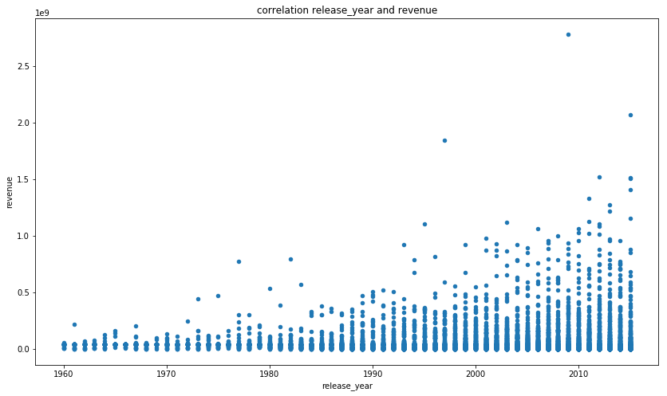

```python
#Test the relationship between revenue and vote average and how the corllete with each other

omv_df.plot(x= 'release_year', y='revenue', kind='scatter', title= "correlation release_year and revenue", figsize=(14,8))
```

### Research Question 2 - which year has the most number of film produced?

```
Text(0.5,1,'Number of movies each year')
```

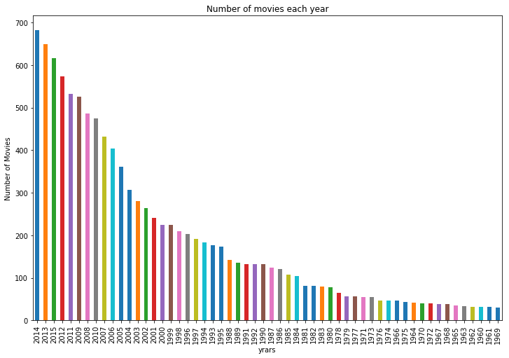

```python
# Continue to explore the data to address your additional research
# the release years and the number of movies for each.
omv_df.release_year.value_counts().plot(kind='bar', figsize=(12,8));
plt.xlabel('yrars')
plt.ylabel('Number of Movies')
plt.title('Number of movies each year')
```

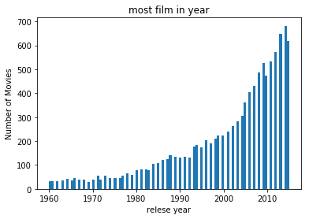

```python
#To check the exact number of each year

plt.xlabel('relese year')
plt.ylabel('Number of Movies')
plt.title('most film in year')
plt.hist(omv_df['release_year'], bins = 100)
```

Answering question 2. The year 2014 is the most year of produced films with 682 movies!

```python
#extract profit by sub bidget from revenue
#add a new column  name 'Movies Profit'
omv_df['Movies Profit'] = omv_df['revenue'] - omv_df['budget']
```

```python
#defining the function
def calculate(column):
    #for max revenues
    maxium_value  = omv_df[column].idxmax()
    omvdf_maxium  = pd.DataFrame(omv_df.loc[maxium_value])

    #for min revenues
    minium_value  = omv_df[column].idxmin()
    omvdf_minium  = pd.DataFrame(omv_df.loc[minium_value])

    #conact both df
    omvdf_maxium_minium = pd.concat([omvdf_maxium, omvdf_minium], axis=1)
    return omvdf_maxium_minium
```

```python
#call the function use below command

omvdf_x = calculate('Movies Profit')
columns = {omvdf_x.columns[0]:'MAx',omvdf_x.columns[1]:'Min'}
omvdf_x = omvdf_x.rename(columns = columns)
omvdf_x
```

|  | MAx | Min |
| --- | --- | --- |
| popularity | 9.43277 | 0.25054 |
| budget | 2.37e+08 | 4.25e+08 |
| revenue | 2.78151e+09 | 1.10876e+07 |
| original_title | Avatar | The Warrior's Way |
| cast | Sam Worthington\|Zoe Saldana\|Sigourney Weaver\|S... | Kate Bosworth\|Jang Dong-gun\|Geoffrey Rush\|Dann... |
| director | James Cameron | Sngmoo Lee |
| runtime | 162 | 100 |
| genres | Action\|Adventure\|Fantasy\|Science Fiction | Adventure\|Fantasy\|Action\|Western\|Thriller |
| vote_count | 8458 | 74 |
| vote_average | 7.1 | 6.4 |
| release_year | 2009 | 2010 |
| Movies Profit | 2.54451e+09 | -4.13912e+08 |

by using thr function above i was able to to get the ptofits of the movies and extract the highst film and the lowest in term of profits.

The highst: Avatar The Lowest: The Warrior's Way

# source :Github

## Conclusions

To conclude, a data set from tmdb with more than 10k films has been investigated.

```python
from subprocess import call
call(['python', '-m', 'nbconvert', 'Investigate_a_Dataset.ipynb'])
```

```
0
```